# Part I - Dataset Exploration ProsperLoan Data

## Introduction

> The Prosper loan dataset contains 113,937 loans with 81 variables on each loan, including loan amount, borrower rate, current loan status, borrower income, and others.

> Peer-to-peer lending platform industry is thriving in recent years. Thousands of investors are making profit through these platforms; thousands of borrowers are getting money more easily. Although these platforms provide creditscore and basic information of borrowers to ensure these lending tradings are in a safety trading environment, there are still thousands of people under risk of losing money.

> Even Prosper, a leading financial peer-to-peer lending platform company, still suffered credit risk issues before. But after their reconstruction and new credit system launched, the credit risk has been improved. It's leading me want to find out stories behind the scenes. Here I will explore this Prosper dataset and try to find out some patterns behind borrowers properties, different Rating type, and how they link to default loan or completed loan.

The Prosper dataset(last updated on 03/11/2014) contains four kinds of variable categories during 2005 to 2014:

- **Loan Status** : The status of the loan list such as Cancelled, Chargedoff, Completed, Current, Defaulted, FinalPaymentInProgress, PastDue.
- **Borrower Data** : Basic properties about borrowers such as credit score, occupation, employment status, etc.
- **Loan Data** : Basic properties about the loan such as length of the loan(term), Borrower APR, etc.
- **Credit Risk Matrices** : Matrices measured the risk of loans, such as Credit grade, Prosper Score, bank card utilization, etc.

## Preliminary Wrangling

```python
# import all packages and set plots to be embedded inline
import numpy as np
import pandas as pd
import matplotlib.pyplot as plt
import seaborn as sb
import datetime

from scipy.stats import norm

# Style and size of graph

sb.set_style('darkgrid')
sb.set(rc={'figure.figsize':(9,7)})

%matplotlib inline
```

```python
!pip install seaborn --upgrade
```

```python
# load dataset
loan_df = pd.read_csv('prosperLoanData.csv')
loan_df.head()
```

|  | ListingKey | ListingNumber | ListingCreationDate | CreditGrade | Term | LoanStatus | ClosedDate | BorrowerAPR | BorrowerRate | LenderYield | ... | LP_ServiceFees | LP_CollectionFees | LP_GrossPrincipalLoss | LP_NetPrincipalLoss | LP_NonPrincipalRecoverypayments | PercentFunded | Recommendations | InvestmentFromFriendsCount | InvestmentFromFriendsAmount | Investors |
| --- | --- | --- | --- | --- | --- | --- | --- | --- | --- | --- | --- | --- | --- | --- | --- | --- | --- | --- | --- | --- | --- |
| 0 | 1021339766868145413AB3B | 193129 | 2007-08-26 19:09:29.263000000 | C | 36 | Completed | 2009-08-14 00:00:00 | 0.16516 | 0.1580 | 0.1380 | ... | -133.18 | 0.0 | 0.0 | 0.0 | 0.0 | 1.0 | 0 | 0 | 0.0 | 258 |
| 1 | 10273602499503308B223C1 | 1209647 | 2014-02-27 08:28:07.900000000 | NaN | 36 | Current | NaN | 0.12016 | 0.0920 | 0.0820 | ... | 0.00 | 0.0 | 0.0 | 0.0 | 0.0 | 1.0 | 0 | 0 | 0.0 | 1 |
| 2 | 0EE9337825851032864889A | 81716 | 2007-01-05 15:00:47.090000000 | HR | 36 | Completed | 2009-12-17 00:00:00 | 0.28269 | 0.2750 | 0.2400 | ... | -24.20 | 0.0 | 0.0 | 0.0 | 0.0 | 1.0 | 0 | 0 | 0.0 | 41 |
| 3 | 0EF5356002482715299901A | 658116 | 2012-10-22 11:02:35.010000000 | NaN | 36 | Current | NaN | 0.12528 | 0.0974 | 0.0874 | ... | -108.01 | 0.0 | 0.0 | 0.0 | 0.0 | 1.0 | 0 | 0 | 0.0 | 158 |
| 4 | 0F023589499656230C5E3E2 | 909464 | 2013-09-14 18:38:39.097000000 | NaN | 36 | Current | NaN | 0.24614 | 0.2085 | 0.1985 | ... | -60.27 | 0.0 | 0.0 | 0.0 | 0.0 | 1.0 | 0 | 0 | 0.0 | 20 |

5 rows × 81 columns

```python
loan_df.info()
```

```
<class 'pandas.core.frame.DataFrame'>
RangeIndex: 113937 entries, 0 to 113936
Data columns (total 81 columns):
ListingKey                             113937 non-null object
ListingNumber                          113937 non-null int64
ListingCreationDate                    113937 non-null object
CreditGrade                            28953 non-null object
Term                                   113937 non-null int64
LoanStatus                             113937 non-null object
ClosedDate                             55089 non-null object
BorrowerAPR                            113912 non-null float64
BorrowerRate                           113937 non-null float64
LenderYield                            113937 non-null float64
EstimatedEffectiveYield                84853 non-null float64
EstimatedLoss                          84853 non-null float64
EstimatedReturn                        84853 non-null float64
ProsperRating (numeric)                84853 non-null float64
ProsperRating (Alpha)                  84853 non-null object
ProsperScore                           84853 non-null float64
ListingCategory (numeric)              113937 non-null int64
BorrowerState                          108422 non-null object
Occupation                             110349 non-null object
EmploymentStatus                       111682 non-null object
EmploymentStatusDuration               106312 non-null float64
IsBorrowerHomeowner                    113937 non-null bool
CurrentlyInGroup                       113937 non-null bool
GroupKey                               13341 non-null object
DateCreditPulled                       113937 non-null object
CreditScoreRangeLower                  113346 non-null float64
CreditScoreRangeUpper                  113346 non-null float64
FirstRecordedCreditLine                113240 non-null object
CurrentCreditLines                     106333 non-null float64
OpenCreditLines                        106333 non-null float64
TotalCreditLinespast7years             113240 non-null float64
OpenRevolvingAccounts                  113937 non-null int64
OpenRevolvingMonthlyPayment            113937 non-null float64
InquiriesLast6Months                   113240 non-null float64
TotalInquiries                         112778 non-null float64
CurrentDelinquencies                   113240 non-null float64
AmountDelinquent                       106315 non-null float64
```

[output cut: 31 more lines]

```
LP_CustomerPayments                    113937 non-null float64
LP_CustomerPrincipalPayments           113937 non-null float64
LP_InterestandFees                     113937 non-null float64
LP_ServiceFees                         113937 non-null float64
LP_CollectionFees                      113937 non-null float64
LP_GrossPrincipalLoss                  113937 non-null float64
LP_NetPrincipalLoss                    113937 non-null float64
LP_NonPrincipalRecoverypayments        113937 non-null float64
PercentFunded                          113937 non-null float64
Recommendations                        113937 non-null int64
InvestmentFromFriendsCount             113937 non-null int64
InvestmentFromFriendsAmount            113937 non-null float64
Investors                              113937 non-null int64
dtypes: bool(3), float64(50), int64(11), object(17)
memory usage: 68.1+ MB
```

```python
loan_df.describe()
```

|  | ListingNumber | Term | BorrowerAPR | BorrowerRate | LenderYield | EstimatedEffectiveYield | EstimatedLoss | EstimatedReturn | ProsperRating (numeric) | ProsperScore | ... | LP_ServiceFees | LP_CollectionFees | LP_GrossPrincipalLoss | LP_NetPrincipalLoss | LP_NonPrincipalRecoverypayments | PercentFunded | Recommendations | InvestmentFromFriendsCount | InvestmentFromFriendsAmount | Investors |
| --- | --- | --- | --- | --- | --- | --- | --- | --- | --- | --- | --- | --- | --- | --- | --- | --- | --- | --- | --- | --- | --- |
| count | 1.139370e+05 | 113937.000000 | 113912.000000 | 113937.000000 | 113937.000000 | 84853.000000 | 84853.000000 | 84853.000000 | 84853.000000 | 84853.000000 | ... | 113937.000000 | 113937.000000 | 113937.000000 | 113937.000000 | 113937.000000 | 113937.000000 | 113937.000000 | 113937.000000 | 113937.000000 | 113937.000000 |
| mean | 6.278857e+05 | 40.830248 | 0.218828 | 0.192764 | 0.182701 | 0.168661 | 0.080306 | 0.096068 | 4.072243 | 5.950067 | ... | -54.725641 | -14.242698 | 700.446342 | 681.420499 | 25.142686 | 0.998584 | 0.048027 | 0.023460 | 16.550751 | 80.475228 |
| std | 3.280762e+05 | 10.436212 | 0.080364 | 0.074818 | 0.074516 | 0.068467 | 0.046764 | 0.030403 | 1.673227 | 2.376501 | ... | 60.675425 | 109.232758 | 2388.513831 | 2357.167068 | 275.657937 | 0.017919 | 0.332353 | 0.232412 | 294.545422 | 103.239020 |
| min | 4.000000e+00 | 12.000000 | 0.006530 | 0.000000 | -0.010000 | -0.182700 | 0.004900 | -0.182700 | 1.000000 | 1.000000 | ... | -664.870000 | -9274.750000 | -94.200000 | -954.550000 | 0.000000 | 0.700000 | 0.000000 | 0.000000 | 0.000000 | 1.000000 |
| 25% | 4.009190e+05 | 36.000000 | 0.156290 | 0.134000 | 0.124200 | 0.115670 | 0.042400 | 0.074080 | 3.000000 | 4.000000 | ... | -73.180000 | 0.000000 | 0.000000 | 0.000000 | 0.000000 | 1.000000 | 0.000000 | 0.000000 | 0.000000 | 2.000000 |
| 50% | 6.005540e+05 | 36.000000 | 0.209760 | 0.184000 | 0.173000 | 0.161500 | 0.072400 | 0.091700 | 4.000000 | 6.000000 | ... | -34.440000 | 0.000000 | 0.000000 | 0.000000 | 0.000000 | 1.000000 | 0.000000 | 0.000000 | 0.000000 | 44.000000 |
| 75% | 8.926340e+05 | 36.000000 | 0.283810 | 0.250000 | 0.240000 | 0.224300 | 0.112000 | 0.116600 | 5.000000 | 8.000000 | ... | -13.920000 | 0.000000 | 0.000000 | 0.000000 | 0.000000 | 1.000000 | 0.000000 | 0.000000 | 0.000000 | 115.000000 |
| max | 1.255725e+06 | 60.000000 | 0.512290 | 0.497500 | 0.492500 | 0.319900 | 0.366000 | 0.283700 | 7.000000 | 11.000000 | ... | 32.060000 | 0.000000 | 25000.000000 | 25000.000000 | 21117.900000 | 1.012500 | 39.000000 | 33.000000 | 25000.000000 | 1189.000000 |

8 rows × 61 columns

##### Assessment

> A few elements will need to be fixed in order to make our analysis possible and more insightful.

> First and foremost, I am going to define which variables and dimensions will be kept to carry out the analysis. Since we have a fairly big data frame (81 columns), I want to narrow down its size in order to answer a few questions, such as what does make one have a more pricey loan than others?. In order to answer I will use the granularity of the next features:
- features = ['ProsperScore', 'ListingCategory (numeric)', 'ListingCategory', 'EmploymentStatus', 'EmploymentStatusDuration', 'IsBorrowerHomeowner', 'CurrentCreditLines', 'OpenRevolvingAccounts', 'DebtToIncomeRatio', 'IncomeVerifiable','IncomeRange' ,'LoanOriginalAmount', 'LoanStatus', 'IncomeMean', 'IncomeRange']

##### Quality:

Changing the ListingCreation format Tidy:

- Changing the IncomeRange format to be able to split into two Income level, the lower and the upper ones
- Creating an IncomeMeans which will account for the means of the two income range levels. This will allow to use this data as an integer (to plot them and look for a correlation)
- Listing Categories, despite being categorical, are in a numeric format. We will want to change this and switch it to string format with the whole category titles spelt out
- Adding a column of WageIncome per month: High, Medium, Low, it might be handy to have a categorical variable instead of the numeric one

```python
# Count total rows in each column which contain null values
loan_df.isnull().sum()
```

```
ListingKey                                  0
ListingNumber                               0
ListingCreationDate                         0
CreditGrade                             84984
Term                                        0
LoanStatus                                  0
ClosedDate                              58848
BorrowerAPR                                25
BorrowerRate                                0
LenderYield                                 0
EstimatedEffectiveYield                 29084
EstimatedLoss                           29084
EstimatedReturn                         29084
ProsperRating (numeric)                 29084
ProsperRating (Alpha)                   29084
ProsperScore                            29084
ListingCategory (numeric)                   0
BorrowerState                            5515
Occupation                               3588
EmploymentStatus                         2255
EmploymentStatusDuration                 7625
IsBorrowerHomeowner                         0
CurrentlyInGroup                            0
GroupKey                               100596
DateCreditPulled                            0
CreditScoreRangeLower                     591
CreditScoreRangeUpper                     591
FirstRecordedCreditLine                   697
CurrentCreditLines                       7604
OpenCreditLines                          7604
                                        ...
TotalProsperLoans                       91852
TotalProsperPaymentsBilled              91852
OnTimeProsperPayments                   91852
ProsperPaymentsLessThanOneMonthLate     91852
ProsperPaymentsOneMonthPlusLate         91852
ProsperPrincipalBorrowed                91852
ProsperPrincipalOutstanding             91852
ScorexChangeAtTimeOfListing             95009
LoanCurrentDaysDelinquent                   0
LoanFirstDefaultedCycleNumber           96985
LoanMonthsSinceOrigination                  0
LoanNumber                                  0
LoanOriginalAmount                          0
LoanOriginationDate                         0
LoanOriginationQuarter                      0
MemberKey                                   0
MonthlyLoanPayment                          0
LP_CustomerPayments                         0
LP_CustomerPrincipalPayments                0
LP_InterestandFees                          0
LP_ServiceFees                              0
LP_CollectionFees                           0
LP_GrossPrincipalLoss                       0
LP_NetPrincipalLoss                         0
LP_NonPrincipalRecoverypayments             0
PercentFunded                               0
Recommendations                             0
InvestmentFromFriendsCount                  0
InvestmentFromFriendsAmount                 0
Investors                                   0
Length: 81, dtype: int64
```

```python
# Check for duplicates in the data
sum(loan_df.duplicated())
```

```
0
```

## Cleaning

```python
#To carry out our analysis, Prosper Score and APR are going to be among of the most important variables. Then, we need to ensure that these variables are fully exploitable.
#Dropping the null means(113,937 - 29,084) we still have 84,853 observations to draw conclusions, which is more than enough
#df.dropna(inplace = True)
loan_df = loan_df[loan_df['ProsperScore'].notnull()]
loan_df = loan_df[~loan_df.BorrowerAPR.isna()]
```

```python
loan_df['ProsperScore'].isna().sum()
```

```
0
```

```python
#Let's look at the count for each values to get a good sense of what the data looks like
loan_df.IncomeRange.value_counts()
```

```
$50,000-74,999    25627
$25,000-49,999    24175
$100,000+         15205
$75,000-99,999    14498
$1-24,999          4654
Not employed        649
$0                   45
Name: IncomeRange, dtype: int64
```

```python
#Let's split the IncomeRange column into two separate columns, and let's get the mean of both after
#First we need to remove the non-numeric characters (out of the hyphen from which we'll split this)
loan_df['IncomeRange'] = loan_df['IncomeRange'].apply(lambda x: x[1:] if x[0] == '$' else x)
loan_df['IncomeRange'] = loan_df['IncomeRange'].apply(lambda x: x.replace(',','').replace('+','').replace('$',''))
```

```python
#removing non numeric characters
da = {'Not employed':'0-0', 'Not displayed':'0-0', '0':'0-0', '100000':'100000-150000'}
loan_df = loan_df.replace({'IncomeRange': da})
```

```python
loan_df.IncomeRange.value_counts()
```

```
50000-74999      25627
25000-49999      24175
100000-150000    15205
75000-99999      14498
1-24999           4654
0-0                694
Name: IncomeRange, dtype: int64
```

```python
# spliting the two existing variables within IncomeRange into two columns
loan_df[['MinRange', 'MaxRange']] = loan_df.IncomeRange.str.split('-', expand = True)
loan_df.head(3)
```

|  | ListingKey | ListingNumber | ListingCreationDate | CreditGrade | Term | LoanStatus | ClosedDate | BorrowerAPR | BorrowerRate | LenderYield | ... | LP_GrossPrincipalLoss | LP_NetPrincipalLoss | LP_NonPrincipalRecoverypayments | PercentFunded | Recommendations | InvestmentFromFriendsCount | InvestmentFromFriendsAmount | Investors | MinRange | MaxRange |
| --- | --- | --- | --- | --- | --- | --- | --- | --- | --- | --- | --- | --- | --- | --- | --- | --- | --- | --- | --- | --- | --- |
| 1 | 10273602499503308B223C1 | 1209647 | 2014-02-27 08:28:07.900000000 | NaN | 36 | Current | NaN | 0.12016 | 0.0920 | 0.0820 | ... | 0.0 | 0.0 | 0.0 | 1.0 | 0 | 0 | 0.0 | 1 | 50000 | 74999 |
| 3 | 0EF5356002482715299901A | 658116 | 2012-10-22 11:02:35.010000000 | NaN | 36 | Current | NaN | 0.12528 | 0.0974 | 0.0874 | ... | 0.0 | 0.0 | 0.0 | 1.0 | 0 | 0 | 0.0 | 158 | 25000 | 49999 |
| 4 | 0F023589499656230C5E3E2 | 909464 | 2013-09-14 18:38:39.097000000 | NaN | 36 | Current | NaN | 0.24614 | 0.2085 | 0.1985 | ... | 0.0 | 0.0 | 0.0 | 1.0 | 0 | 0 | 0.0 | 20 | 100000 | 150000 |

3 rows × 83 columns

```python
#Coverting the data type from String to Integer
def str_to_int(input):
    return np.int(float(input))
```

```python
#The values need to be changed from string to integer
loan_df['MinRange'] = loan_df['MinRange'].apply(str_to_int)
loan_df['MaxRange'] = loan_df['MaxRange'].apply(str_to_int)
print(loan_df[['MinRange','MaxRange']].info())
```

```
<class 'pandas.core.frame.DataFrame'>
Int64Index: 84853 entries, 1 to 113936
Data columns (total 2 columns):
MinRange    84853 non-null int64
MaxRange    84853 non-null int64
dtypes: int64(2)
memory usage: 1.9 MB
None
```

```python
#Lets create the MeanIncome variable which will help us calculate correlation between this varible and others:' ))
loan_df['MeanIncome'] = loan_df[['MinRange', 'MaxRange']].mean(axis=1)
loan_df['MeanIncome'] = loan_df['MeanIncome'].apply(str_to_int)
loan_df.head(3)
```

|  | ListingKey | ListingNumber | ListingCreationDate | CreditGrade | Term | LoanStatus | ClosedDate | BorrowerAPR | BorrowerRate | LenderYield | ... | LP_NetPrincipalLoss | LP_NonPrincipalRecoverypayments | PercentFunded | Recommendations | InvestmentFromFriendsCount | InvestmentFromFriendsAmount | Investors | MinRange | MaxRange | MeanIncome |
| --- | --- | --- | --- | --- | --- | --- | --- | --- | --- | --- | --- | --- | --- | --- | --- | --- | --- | --- | --- | --- | --- |
| 1 | 10273602499503308B223C1 | 1209647 | 2014-02-27 08:28:07.900000000 | NaN | 36 | Current | NaN | 0.12016 | 0.0920 | 0.0820 | ... | 0.0 | 0.0 | 1.0 | 0 | 0 | 0.0 | 1 | 50000 | 74999 | 62499 |
| 3 | 0EF5356002482715299901A | 658116 | 2012-10-22 11:02:35.010000000 | NaN | 36 | Current | NaN | 0.12528 | 0.0974 | 0.0874 | ... | 0.0 | 0.0 | 1.0 | 0 | 0 | 0.0 | 158 | 25000 | 49999 | 37499 |
| 4 | 0F023589499656230C5E3E2 | 909464 | 2013-09-14 18:38:39.097000000 | NaN | 36 | Current | NaN | 0.24614 | 0.2085 | 0.1985 | ... | 0.0 | 0.0 | 1.0 | 0 | 0 | 0.0 | 20 | 100000 | 150000 | 125000 |

3 rows × 84 columns

```python
def truncate_extra(row):
    if len(row.ListingCreationDate)==29:
        return row.ListingCreationDate[:-10]
    else:
        return row.ListingCreationDate
```

```python
loan_df.ListingCreationDate = loan_df.apply(truncate_extra,axis=1)
loan_df.ListingCreationDate = loan_df.ListingCreationDate.apply(lambda x: datetime.datetime.strptime(x, "%Y-%m-%d %H:%M:%S"))
loan_df.head(3)
```

|  | ListingKey | ListingNumber | ListingCreationDate | CreditGrade | Term | LoanStatus | ClosedDate | BorrowerAPR | BorrowerRate | LenderYield | ... | LP_NetPrincipalLoss | LP_NonPrincipalRecoverypayments | PercentFunded | Recommendations | InvestmentFromFriendsCount | InvestmentFromFriendsAmount | Investors | MinRange | MaxRange | MeanIncome |
| --- | --- | --- | --- | --- | --- | --- | --- | --- | --- | --- | --- | --- | --- | --- | --- | --- | --- | --- | --- | --- | --- |
| 1 | 10273602499503308B223C1 | 1209647 | 2014-02-27 08:28:07 | NaN | 36 | Current | NaN | 0.12016 | 0.0920 | 0.0820 | ... | 0.0 | 0.0 | 1.0 | 0 | 0 | 0.0 | 1 | 50000 | 74999 | 62499 |
| 3 | 0EF5356002482715299901A | 658116 | 2012-10-22 11:02:35 | NaN | 36 | Current | NaN | 0.12528 | 0.0974 | 0.0874 | ... | 0.0 | 0.0 | 1.0 | 0 | 0 | 0.0 | 158 | 25000 | 49999 | 37499 |
| 4 | 0F023589499656230C5E3E2 | 909464 | 2013-09-14 18:38:39 | NaN | 36 | Current | NaN | 0.24614 | 0.2085 | 0.1985 | ... | 0.0 | 0.0 | 1.0 | 0 | 0 | 0.0 | 20 | 100000 | 150000 | 125000 |

3 rows × 84 columns

```python
def classify(row):
    if row["StatedMonthlyIncome"]<2000:
        return 'Low'
    if row["StatedMonthlyIncome"]<7500:
        return 'Medium'
    else:
        return 'High'
```

```python
loan_df['WageCategory'] = loan_df.apply(classify, axis=1)
loan_df.sample(4)
```

|  | ListingKey | ListingNumber | ListingCreationDate | CreditGrade | Term | LoanStatus | ClosedDate | BorrowerAPR | BorrowerRate | LenderYield | ... | LP_NonPrincipalRecoverypayments | PercentFunded | Recommendations | InvestmentFromFriendsCount | InvestmentFromFriendsAmount | Investors | MinRange | MaxRange | MeanIncome | WageCategory |
| --- | --- | --- | --- | --- | --- | --- | --- | --- | --- | --- | --- | --- | --- | --- | --- | --- | --- | --- | --- | --- | --- |
| 60937 | 82A63562869927983F6F298 | 670437 | 2012-11-14 13:17:21 | NaN | 60 | Current | NaN | 0.27462 | 0.2489 | 0.2389 | ... | 0.0 | 1.0 | 0 | 0 | 0.0 | 82 | 25000 | 49999 | 37499 | Medium |
| 34821 | FCA63562117554487B7AC05 | 660565 | 2012-10-25 07:41:45 | NaN | 36 | Current | NaN | 0.17192 | 0.1359 | 0.1259 | ... | 0.0 | 1.0 | 0 | 0 | 0.0 | 11 | 100000 | 150000 | 125000 | High |
| 41780 | 14A435474897091095FDF90 | 591601 | 2012-05-22 04:28:18 | NaN | 36 | Completed | 2012-09-24 00:00:00 | 0.33973 | 0.2999 | 0.2899 | ... | 0.0 | 1.0 | 0 | 0 | 0.0 | 31 | 25000 | 49999 | 37499 | Medium |
| 99737 | B9403594752700870D1FC02 | 996290 | 2013-11-04 15:08:11 | NaN | 60 | Current | NaN | 0.16713 | 0.1440 | 0.1340 | ... | 0.0 | 1.0 | 0 | 0 | 0.0 | 1 | 50000 | 74999 | 62499 | Medium |

4 rows × 85 columns

```python
# Decode ListingCategory (numeric) feature by creating an explanatory column
list_cat = {0 : 'Not Available', 1 : 'Debt Consolidation', 2 : 'Home Improvement', 3: 'Business',
             4 : 'Personal Loan', 5 : 'Student Use', 6 : 'Auto', 7 : 'Other', 8 : 'Baby&Adoption',
             9 : 'Boat', 10 : 'Cosmetic Procedure', 11 : 'Engagement Ring', 12 : 'Green Loans',
             13 : 'Household Expenses', 14 : 'Large Purchases', 15 : 'Medical/Dental', 16 : 'Motorcycle',
             17 : 'RV', 18 : 'Taxes', 19 : 'Vacation', 20 : 'Wedding Loans'}

loan_df['ListingCategory'] = loan_df['ListingCategory (numeric)'].map(list_cat)
```

```python
# Define columns of interest for this analysis
Targets = ['ProsperScore', 'ListingCategory (numeric)', 'ListingCategory', 'EmploymentStatus', 'EmploymentStatusDuration',
            'IsBorrowerHomeowner', 'CurrentCreditLines', 'OpenRevolvingAccounts', 'DebtToIncomeRatio',
            'IncomeVerifiable','IncomeRange' ,'LoanOriginalAmount', 'LoanStatus', 'MeanIncome',
            'ProsperRating (Alpha)', 'StatedMonthlyIncome', 'Term', 'BorrowerAPR', 'ListingCreationDate']
```

```python
# Numberical vs Categorical features
numeric_features = ['ProsperScore', 'EmploymentStatusDuration', 'CurrentCreditLines', 'OpenRevolvingAccounts',
               'DebtToIncomeRatio', 'LoanOriginalAmount', 'MeanIncome', 'StatedMonthlyIncome', 'BorrowerAPR']
categoric_features = ['LoanStatus', 'ListingCategory','EmploymentStatus', 'IsBorrowerHomeowner',
                  'IncomeVerifiable', 'IncomeRange','ProsperRating (Alpha)', 'Term', 'ListingCreationDate']
```

```python
loan_df = loan_df[Targets]
loan_df.head(2)
```

|  | ProsperScore | ListingCategory (numeric) | ListingCategory | EmploymentStatus | EmploymentStatusDuration | IsBorrowerHomeowner | CurrentCreditLines | OpenRevolvingAccounts | DebtToIncomeRatio | IncomeVerifiable | IncomeRange | LoanOriginalAmount | LoanStatus | MeanIncome | ProsperRating (Alpha) | StatedMonthlyIncome | Term | BorrowerAPR | ListingCreationDate |
| --- | --- | --- | --- | --- | --- | --- | --- | --- | --- | --- | --- | --- | --- | --- | --- | --- | --- | --- | --- |
| 1 | 7.0 | 2 | Home Improvement | Employed | 44.0 | False | 14.0 | 13 | 0.18 | True | 50000-74999 | 10000 | Current | 62499 | A | 6125.0 | 36 | 0.12016 | 2014-02-27 08:28:07 |
| 3 | 9.0 | 16 | Motorcycle | Employed | 113.0 | True | 5.0 | 7 | 0.15 | True | 25000-49999 | 10000 | Current | 37499 | A | 2875.0 | 36 | 0.12528 | 2012-10-22 11:02:35 |

```python
loan_df.info()
```

```
<class 'pandas.core.frame.DataFrame'>
Int64Index: 84853 entries, 1 to 113936
Data columns (total 19 columns):
ProsperScore                 84853 non-null float64
ListingCategory (numeric)    84853 non-null int64
ListingCategory              84853 non-null object
EmploymentStatus             84853 non-null object
EmploymentStatusDuration     84834 non-null float64
IsBorrowerHomeowner          84853 non-null bool
CurrentCreditLines           84853 non-null float64
OpenRevolvingAccounts        84853 non-null int64
DebtToIncomeRatio            77557 non-null float64
IncomeVerifiable             84853 non-null bool
IncomeRange                  84853 non-null object
LoanOriginalAmount           84853 non-null int64
LoanStatus                   84853 non-null object
MeanIncome                   84853 non-null int64
ProsperRating (Alpha)        84853 non-null object
StatedMonthlyIncome          84853 non-null float64
Term                         84853 non-null int64
BorrowerAPR                  84853 non-null float64
ListingCreationDate          84853 non-null datetime64[ns]
dtypes: bool(2), datetime64[ns](1), float64(6), int64(5), object(5)
memory usage: 11.8+ MB
```

### Explanatory Data Analysis

```python
loan_df.describe()
```

|  | ProsperScore | ListingCategory (numeric) | EmploymentStatusDuration | CurrentCreditLines | OpenRevolvingAccounts | DebtToIncomeRatio | LoanOriginalAmount | MeanIncome | StatedMonthlyIncome | Term | BorrowerAPR |
| --- | --- | --- | --- | --- | --- | --- | --- | --- | --- | --- | --- |
| count | 84853.000000 | 84853.000000 | 84834.000000 | 84853.000000 | 84853.000000 | 77557.000000 | 84853.000000 | 84853.000000 | 8.485300e+04 | 84853.000000 | 84853.000000 |
| mean | 5.950067 | 3.312647 | 103.055320 | 10.508032 | 7.386292 | 0.258752 | 9083.440515 | 67594.082708 | 5.931175e+03 | 42.486135 | 0.226658 |
| std | 2.376501 | 4.364277 | 97.078884 | 5.317401 | 4.515977 | 0.318326 | 6287.860058 | 33585.117095 | 8.239944e+03 | 11.640346 | 0.079916 |
| min | 1.000000 | 0.000000 | 0.000000 | 0.000000 | 0.000000 | 0.000000 | 1000.000000 | 0.000000 | 0.000000e+00 | 12.000000 | 0.045830 |
| 25% | 4.000000 | 1.000000 | 30.000000 | 7.000000 | 4.000000 | 0.150000 | 4000.000000 | 37499.000000 | 3.434000e+03 | 36.000000 | 0.163280 |
| 50% | 6.000000 | 1.000000 | 74.000000 | 10.000000 | 7.000000 | 0.220000 | 7500.000000 | 62499.000000 | 5.000000e+03 | 36.000000 | 0.219450 |
| 75% | 8.000000 | 3.000000 | 148.000000 | 13.000000 | 10.000000 | 0.320000 | 13500.000000 | 87499.000000 | 7.083333e+03 | 60.000000 | 0.292540 |
| max | 11.000000 | 20.000000 | 755.000000 | 59.000000 | 50.000000 | 10.010000 | 35000.000000 | 125000.000000 | 1.750003e+06 | 60.000000 | 0.423950 |

```python
#Let's look at the data dimension
print("rows=",loan_df.shape[0],", columns=",loan_df.shape[1])
loan_df.head(3)
```

```
rows= 84853 , columns= 19
```

|  | ProsperScore | ListingCategory (numeric) | ListingCategory | EmploymentStatus | EmploymentStatusDuration | IsBorrowerHomeowner | CurrentCreditLines | OpenRevolvingAccounts | DebtToIncomeRatio | IncomeVerifiable | IncomeRange | LoanOriginalAmount | LoanStatus | MeanIncome | ProsperRating (Alpha) | StatedMonthlyIncome | Term | BorrowerAPR | ListingCreationDate |
| --- | --- | --- | --- | --- | --- | --- | --- | --- | --- | --- | --- | --- | --- | --- | --- | --- | --- | --- | --- |
| 1 | 7.0 | 2 | Home Improvement | Employed | 44.0 | False | 14.0 | 13 | 0.18 | True | 50000-74999 | 10000 | Current | 62499 | A | 6125.000000 | 36 | 0.12016 | 2014-02-27 08:28:07 |
| 3 | 9.0 | 16 | Motorcycle | Employed | 113.0 | True | 5.0 | 7 | 0.15 | True | 25000-49999 | 10000 | Current | 37499 | A | 2875.000000 | 36 | 0.12528 | 2012-10-22 11:02:35 |
| 4 | 4.0 | 2 | Home Improvement | Employed | 44.0 | True | 19.0 | 6 | 0.26 | True | 100000-150000 | 15000 | Current | 125000 | D | 9583.333333 | 36 | 0.24614 | 2013-09-14 18:38:39 |

```python
loan_df.EmploymentStatus.value_counts()
```

```
Employed         67310
Full-time         7927
Self-employed     4538
Other             3806
Not employed       649
Retired            367
Part-time          256
Name: EmploymentStatus, dtype: int64
```

```python
loan_df.LoanStatus.value_counts()
```

```
Current                   56576
Completed                 19664
Chargedoff                 5336
Defaulted                  1005
Past Due (1-15 days)        806
Past Due (31-60 days)       363
Past Due (61-90 days)       313
Past Due (91-120 days)      304
Past Due (16-30 days)       265
FinalPaymentInProgress      205
Past Due (>120 days)         16
Name: LoanStatus, dtype: int64
```

```python
loan_df.IncomeVerifiable.value_counts()
```

```
True     77520
False     7333
Name: IncomeVerifiable, dtype: int64
```

```python
loan_df.IsBorrowerHomeowner.value_counts()
```

```
True     44848
False    40005
Name: IsBorrowerHomeowner, dtype: int64
```

```python
#In order to not overwhelm our future plots (mainly scatter plots), we are randomly sampling our population dataset.
#6000 observations should be more than enough to draw conclusions on the population and be confident about it
#samples = np.random.choice(df.shape[0], 3000, replace = False)
#diamonds_samp = diamonds.loc[samples,:]
df_instance = loan_df.sample(6000,replace = False)
```

```python
df_instance.head()
```

|  | ProsperScore | ListingCategory (numeric) | ListingCategory | EmploymentStatus | EmploymentStatusDuration | IsBorrowerHomeowner | CurrentCreditLines | OpenRevolvingAccounts | DebtToIncomeRatio | IncomeVerifiable | IncomeRange | LoanOriginalAmount | LoanStatus | MeanIncome | ProsperRating (Alpha) | StatedMonthlyIncome | Term | BorrowerAPR | ListingCreationDate |
| --- | --- | --- | --- | --- | --- | --- | --- | --- | --- | --- | --- | --- | --- | --- | --- | --- | --- | --- | --- |
| 85047 | 4.0 | 1 | Debt Consolidation | Employed | 77.0 | True | 14.0 | 10 | 0.42 | True | 25000-49999 | 4000 | Current | 37499 | HR | 3750.000000 | 36 | 0.35797 | 2012-10-07 18:28:32 |
| 97448 | 6.0 | 1 | Debt Consolidation | Employed | 13.0 | True | 2.0 | 2 | 0.22 | True | 25000-49999 | 4000 | Current | 37499 | D | 3333.333333 | 36 | 0.27060 | 2012-08-18 06:52:08 |
| 32870 | 7.0 | 3 | Business | Employed | 185.0 | False | 5.0 | 1 | 0.10 | True | 100000-150000 | 15000 | Current | 125000 | C | 10000.000000 | 36 | 0.24246 | 2012-01-22 09:16:22 |
| 88704 | 4.0 | 1 | Debt Consolidation | Employed | 304.0 | True | 15.0 | 12 | 0.55 | True | 25000-49999 | 10000 | Current | 37499 | D | 3750.000000 | 36 | 0.25330 | 2013-10-08 15:10:57 |
| 46923 | 7.0 | 2 | Home Improvement | Employed | 7.0 | True | 13.0 | 12 | 0.27 | True | 100000-150000 | 25000 | Current | 125000 | C | 9166.666667 | 36 | 0.20217 | 2014-01-28 14:25:48 |

### What is the structure of your dataset?

> There are 113937 loan records in this dataset with 81 features

[output not shown]

### What is/are the main feature(s) of interest in your dataset?

First and foremost, I am going to define which variables and dimensions will be kept to carry out the analysis. Since we have a fairly big data frame (81 columns), I want to narrow down its size in order to answer a few questions, such as what does make one have a more pricey loan than others?. In order to answer I will use the granularity of the next features:

features = ['ProsperScore', 'ListingCategory (numeric)', 'ListingCategory', 'EmploymentStatus', 'EmploymentStatusDuration', 'IsBorrowerHomeowner', 'CurrentCreditLines', 'OpenRevolvingAccounts', 'DebtToIncomeRatio', 'IncomeVerifiable','IncomeRange' ,'LoanOriginalAmount', 'LoanStatus', 'IncomeMean', 'IncomeRange']

### What features in the dataset do you think will help support your investigation into your feature(s) of interest?

- Changing the IncomeRange format to be able to split into two Income level, the lower and the upper ones
- Creating an IncomeMeans which will account for the means of the two income range levels. This will allow to use this data as an integer (to plot them and look for a correlation)
- Listing Categories, despite being categorical, are in a numeric format. We will want to change this and switch it to string format with the whole category titles spelt out
- Adding a column of WageIncome per month: High, Medium, Low, it might be handy to have a categorical variable instead of the numeric one

### Univariate Exploration

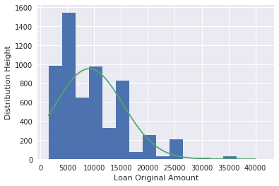

```python
# create a histogram of the data
bin_size = 2500
bin_edges = np.arange(1500, 40000 + bin_size, bin_size)
plt.hist(data = df_instance, x = 'LoanOriginalAmount', bins = bin_edges);

# overlay a theoretical normal distribution on top
samp_mean = df_instance['LoanOriginalAmount'].mean()
samp_sd = df_instance['LoanOriginalAmount'].std()

from scipy.stats import norm
x = np.linspace(1500, 40000, 2500)
y = norm.pdf(x, samp_mean, samp_sd) # normal distribution heights
y *= df_instance.shape[0] * bin_size # scale the distribution height

plt.xlabel('Loan Original Amount')
plt.ylabel('Distribution Height')
plt.plot(x, y);
```

- Lets look at the distribution of Loan amount lended by Prosper.
- As we can see the vast majority of loans doesnt exceed 15,000$.
- In addition, the bell curve can help us see if there is a normal distribution underneath, which is not the case here.

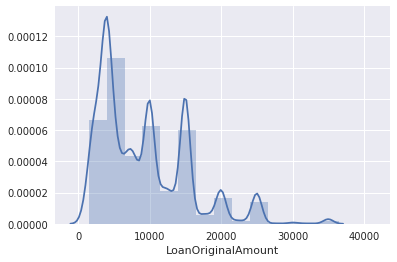

```python
#Lets look at the distribution using the population dataset

sb.distplot(loan_df['LoanOriginalAmount'], hist_kws = {'alpha' : 1/3}, bins = bin_edges)
plt.show();
```

- We can see using proportion and a density line that our Loan Amount distribution is clearly peaking around 5,000$,
- Similarly, the density line does not look normal

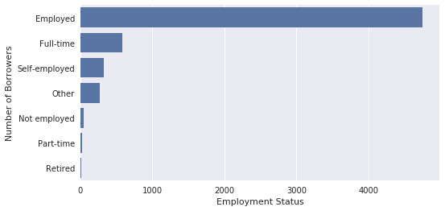

```python
#Lets look at the numbers of borrowers by Employment Status
# Plot for EmploymentStatus
plt.figure(figsize=[8, 4])
base_color = sb.color_palette()[0]
# Order the categorical variable type
cat_order = df_instance['EmploymentStatus'].value_counts().index

sb.countplot(data = df_instance, y = 'EmploymentStatus', color = base_color, order=cat_order)
plt.xlabel('Employment Status')
plt.ylabel('Number of Borrowers');
```

> The majority of borrowers are employed, reason why getting a loan without a job is not known to be easy.

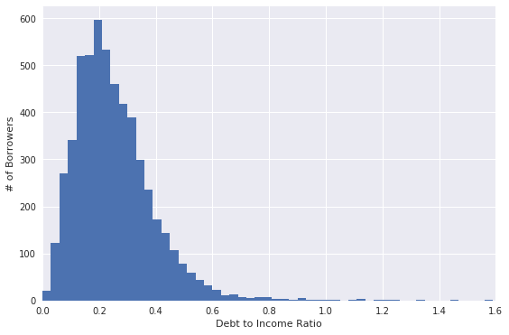

```python
#The Debt to Income ratio is a good metric to look at the level of debt borrowers are committing themselves
# Plot a standard-scaled plot for DebtToIncomeRatio
binsize = 0.03
bins = np.arange(0, df_instance['DebtToIncomeRatio'].max()+binsize, binsize)

plt.figure(figsize=[9, 6])
plt.hist(data = df_instance[df_instance['DebtToIncomeRatio'].notnull()], x = 'DebtToIncomeRatio', bins = bins)
plt.xlabel('Debt to Income Ratio')
plt.ylabel('# of Borrowers')
plt.xlim(0,1.6);
```

The distribution looks pretty normal, slightly right-skewed.

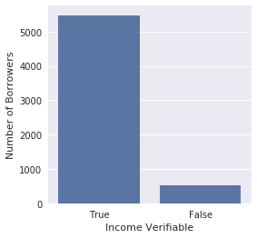

```python
#How many of these 6,000 borrowers (sample) have their income verifiable
# Plot for IncomeVerifiable
plt.figure(figsize=[4, 4])

# Order the categorical variable type
cat_order = df_instance['IncomeVerifiable'].value_counts().index

sb.countplot(data = df_instance, x = 'IncomeVerifiable', color = base_color, order=cat_order)
plt.xlabel('Income Verifiable')
plt.ylabel('Number of Borrowers');
```

> The possiblility of getting your loan request approved without your income verified is low.

### Bivariate Exploration

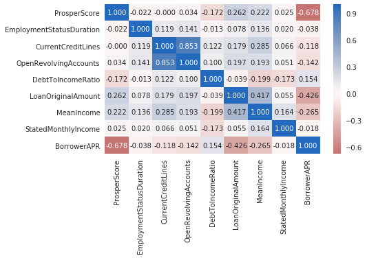

```python
# A correlarion grid a a great way to check the correlarion/relationship of multiple variables
# correlation plot
plt.figure(figsize = [7, 4])
sb.heatmap(df_instance[numeric_features].corr(), annot = True, fmt = '.3f',
           cmap = 'vlag_r', center = 0)
plt.show()
```

We can see that the OpenRevolvingAccount and the CurrentCreditLines have a very strong correlation (0.85). Let's explore this a bit more by plotting them on a scatter plot.

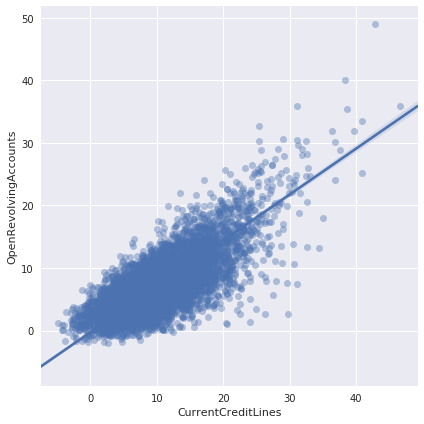

```python
# Scatter plot of CurrentCreditLines against OpenRevolvingAccounts.


g = sb.FacetGrid(data = df_instance, size = 6)

g.map(sb.regplot, 'CurrentCreditLines', 'OpenRevolvingAccounts', scatter_kws={'alpha':0.4},y_jitter = 2, x_jitter = 5, fit_reg= True)
#g.set(xscale = 'log')
#plt.xticks(ticks, labels)
#plt.legend(['False','True']);
plt.show()
```

Scatter plot of CurrentCreditLines against OpenRevolvingAccounts. We can see that the regression line is clear about the direction of the relationship

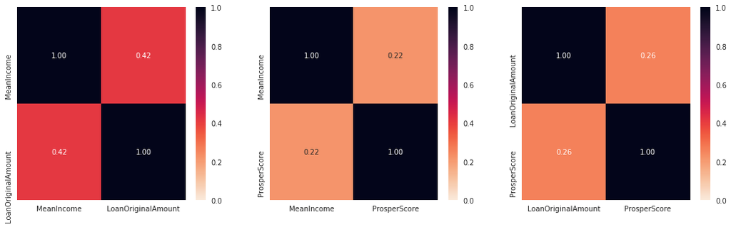

```python
#In order to get insights on what makes ones get an high loan amount versus a low loan amount. Lets look at the
#correlation between IncomeMean/LoanAmount, IncomeMean/ProsperScore and LoanAmount/ProsperScore:'))
plt.figure(figsize = [18, 5])

plt.subplot(1,3,1)
stats = ['MeanIncome','LoanOriginalAmount']
sb.heatmap(df_instance[stats].corr(), cmap= 'rocket_r', annot= True, fmt = '.2f', vmin = 0)


plt.subplot(1,3,2)
sb.heatmap(df_instance[['MeanIncome', 'ProsperScore']].corr(), cmap= 'rocket_r', annot= True, fmt = '.2f', vmin = 0)


plt.subplot(1,3,3)
sb.heatmap(df_instance[['LoanOriginalAmount', 'ProsperScore']].corr(), cmap= 'rocket_r', annot= True, fmt = '.2f', vmin = 0);
```

We can see that they all three have an existing correlation, with IncomeMean/LoanAmount being fairly strong (above 0.4). Understanding how these three metrics work, we can draw the conclusions that a higher Income drives a better ProsperScore, which drives a higher loan amount. A higher income might also mean that borrower might have a more expensive project to finance, which then drive a higher loan amount.

Let's explore all of this a bit more below.

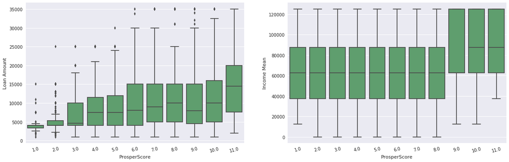

```python
plt.figure(figsize = [20, 6])
base_color = sb.color_palette()[1]

plt.subplot(1,2,1)
sb.boxplot(data = df_instance, x = 'ProsperScore', y = 'LoanOriginalAmount' ,color = base_color)
plt.xticks(rotation = 15)
plt.ylabel('Loan Amount')


plt.subplot(1,2,2)
sb.boxplot(data = df_instance, x = 'ProsperScore', y = 'MeanIncome' ,color = base_color)
plt.xticks(rotation = 15)
plt.ylabel('Income Mean')
plt.show()
```

We can see that the higher the Prosper, the higher the loan amount tends to be. Similarly, as we saw on the heatmap before, the Prosper score tends to be correlated with a a higher income mean

```python
bin_edges= [0, 3, 5, 8, 11]
bin_edges

bin_names = ['Bad', 'Average', 'Good', 'Very Good']
bin_names

df_instance['ProsperGroup']=pd.cut(df_instance['ProsperScore'], bin_edges, labels=bin_names)
loan_df['ProsperGroup']=pd.cut(loan_df['ProsperScore'], bin_edges, labels=bin_names)
```

- To not lose ourselves int the rabbit hole of ProsperGroup,
- we are going to cut them into groups.The 4 groups will be: Bad, Average, Good & Very Good.

```python
df_instance.head(3)
```

|  | ProsperScore | ListingCategory (numeric) | ListingCategory | EmploymentStatus | EmploymentStatusDuration | IsBorrowerHomeowner | CurrentCreditLines | OpenRevolvingAccounts | DebtToIncomeRatio | IncomeVerifiable | IncomeRange | LoanOriginalAmount | LoanStatus | MeanIncome | ProsperRating (Alpha) | StatedMonthlyIncome | Term | BorrowerAPR | ListingCreationDate | ProsperGroup |
| --- | --- | --- | --- | --- | --- | --- | --- | --- | --- | --- | --- | --- | --- | --- | --- | --- | --- | --- | --- | --- |
| 44194 | 5.0 | 2 | Home Improvement | Employed | 2.0 | True | 5.0 | 3 | 0.12 | True | 25000-49999 | 2500 | Current | 37499 | B | 2500.000000 | 36 | 0.20053 | 2013-07-26 15:10:46 | Average |
| 30125 | 6.0 | 1 | Debt Consolidation | Employed | 125.0 | True | 12.0 | 10 | 0.25 | True | 50000-74999 | 6000 | Current | 62499 | A | 5666.666667 | 12 | 0.12781 | 2013-03-25 15:55:10 | Good |
| 19633 | 7.0 | 2 | Home Improvement | Employed | 30.0 | True | 8.0 | 2 | 0.34 | True | 100000-150000 | 28000 | Current | 125000 | B | 9333.333333 | 36 | 0.16732 | 2013-11-24 12:41:00 | Good |

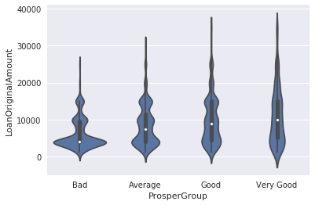

```python
base_color = sb.color_palette()[0]
bins = np.arange(0, 35000, 1500)
sb.violinplot(data = df_instance, x = 'ProsperGroup' , y = 'LoanOriginalAmount', bins=bins, color = base_color)
plt.show()
```

- The prosper score is undeniably helping to get a higher loan amount

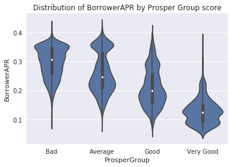

```python
base_color = sb.color_palette()[0]
bins = np.arange(0, 35000, 1500)
sb.violinplot(data = df_instance, x = 'ProsperGroup' , y = 'BorrowerAPR', bins=bins, color = base_color)
plt.title('Distribution of BorrowerAPR by Prosper Group score')
plt.show()
```

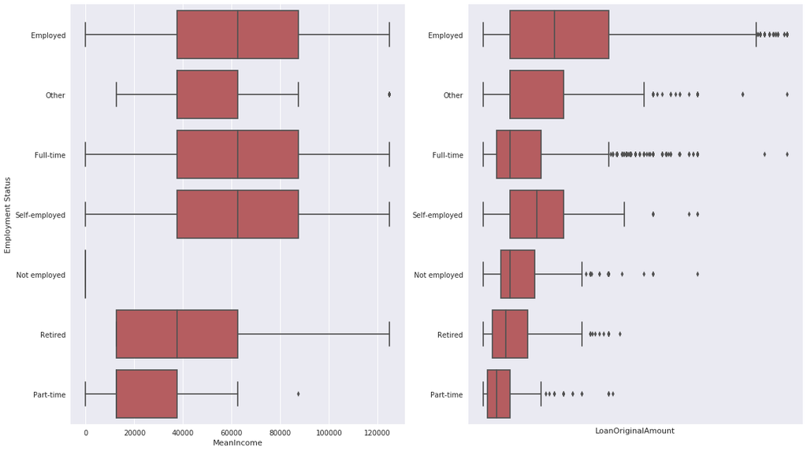

```python
#What s the Employment Status that helps us get a better loan ? What about the Income Amount?
plt.figure(figsize = [16, 9])
base_color = sb.color_palette()[2]

plt.subplot(1,2,1)
sb.boxplot(data = loan_df, y = 'EmploymentStatus', x = 'MeanIncome' ,color = base_color, orient='h')
plt.xticks(rotation = 0)
plt.ylabel('Employment Status')

plt.subplot(1,2,2)
sb.boxplot(data = loan_df, y = 'EmploymentStatus', x = 'LoanOriginalAmount' ,color = base_color, orient='h')
plt.xticks([])
plt.ylabel('');

plt.tight_layout()
```

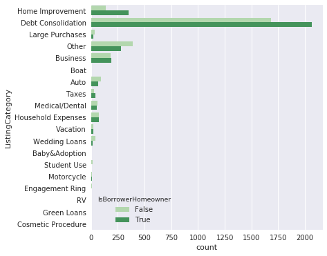

```python
#Which Categories account for the more important number of loans lended?

#Is there any difference between Home owner or not?
# LoanType vs IsBorrowerHomeOwner
plt.figure(figsize = [6, 6])

sb.countplot(data = df_instance, y = 'ListingCategory', hue = 'IsBorrowerHomeowner', palette = 'Greens', orient="h")
plt.xticks(rotation=0);
```

Let's now look at the Category for which the loan amount is the highest. Let's look at the 5 Categories for which we have the biggest loan medians.

```python
#l1 = df_instance.groupby(['ListingCategory']).agg(loan_amount_median=('LoanOriginalAmount', 'median'))
#l2 = df_instance.groupby(['ListingCategory']).agg(loan_amount_mean=('LoanOriginalAmount', 'mean'))

l1 = df_instance.groupby('ListingCategory')['LoanOriginalAmount'].agg([('loan_amount_median','median')])
l2 = df_instance.groupby('ListingCategory')['LoanOriginalAmount'].agg([('loan_amount_mean','mean')])
```

```python
listing_df = l1.join(l2)
listing_df = listing_df.sort_values(['loan_amount_median'], ascending= False).head()
listing_df.reset_index(inplace= True)
listing_df['ListingCategory'] = listing_df['ListingCategory'].astype(str)
listing_df.head()
```

|  | ListingCategory | loan_amount_median | loan_amount_mean |
| --- | --- | --- | --- |
| 0 | Green Loans | 15000 | 10300.000000 |
| 1 | Baby&Adoption | 10250 | 10937.500000 |
| 2 | Debt Consolidation | 10000 | 10338.545965 |
| 3 | RV | 8500 | 9279.500000 |
| 4 | Large Purchases | 7500 | 9251.741379 |

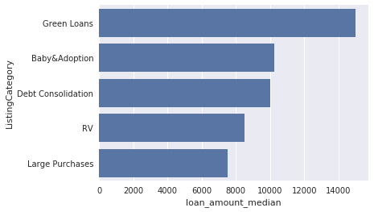

```python
# plotting

base_color = sb.color_palette()[0]
sb.barplot(data = listing_df, x = 'loan_amount_median', y = 'ListingCategory',
               color = base_color, ci = 'sd');
```

> We can see the 5 more important loan amount (by the median) by Category:'))

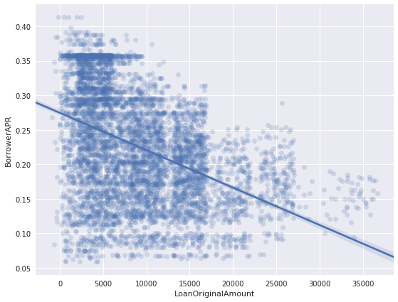

```python
plt.figure(figsize = [9, 7])
sb.regplot(data = df_instance, x = 'LoanOriginalAmount', y = 'BorrowerAPR', x_jitter = 2000 ,scatter_kws={'alpha':0.2});
```

> Let's look at how borrower APR and loan original amount are related to one another for all of the data.
> - This plot shows that at different size of the loan amount, the APR has a large range, but the range of APR decrease with the increase of loan amount. Overall, the borrower APR is negatively correlated with loan amount.

### Multivariate Exploration

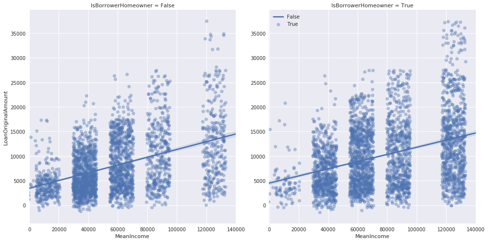

```python
#Lets look at the relationship between Loan Amount and Income Mean, with a third variable:
#Which is, is the Borrower Home Owner or not?
plt.figure(figsize = [13, 11])

g = sb.FacetGrid(data = df_instance, col = 'IsBorrowerHomeowner', size = 7)
g.map(sb.regplot, 'MeanIncome', 'LoanOriginalAmount', y_jitter = 2500, x_jitter = 8000,scatter_kws={'alpha':0.4}, fit_reg= True)

plt.legend(['False','True'])
plt.xlim(-100,140000)
plt.show()
```

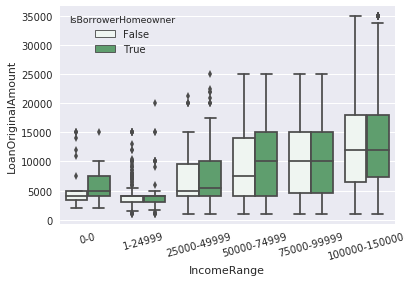

```python
income_categories = ['0-0','1-24999' ,'25000-49999', '50000-74999', '75000-99999', '100000-150000']
incomecategories = pd.api.types.CategoricalDtype(ordered = True, categories= income_categories)
df_instance['IncomeRange'] = df_instance['IncomeRange'].astype(incomecategories)

base_color = sb.color_palette()[1]
sb.boxplot(data = df_instance, x = 'IncomeRange', y = 'LoanOriginalAmount',hue = 'IsBorrowerHomeowner' ,color = base_color)
plt.xticks(rotation = 15);
```

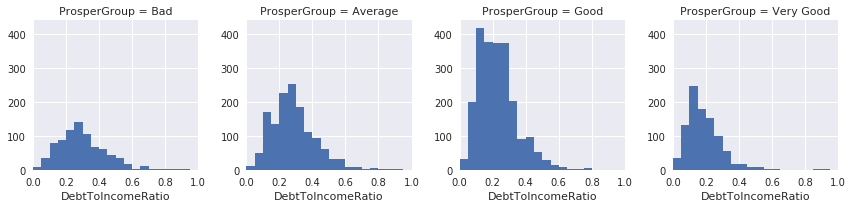

```python
#Lets now look at how the Debt to Income ratio distribution is changing based on the ProsperGroup Score.

bins = np.arange(0, 1, 0.05)
g = sb.FacetGrid(data = df_instance, col = 'ProsperGroup', margin_titles = True)
g.map(plt.hist,'DebtToIncomeRatio', bins=bins)
plt.xlim(0,1)
plt.show()
```

### Conclusion:

- To sum up our findings, we can say that being employed and having your income verifiable seem to be a great way to get your loan approved. In addition, the higher your income is, the better your Prosper score can be and the higher your loan can be too. Prosper seems to have good reasons to believe that their way to assess someone's request is fair and relevant since we have seen that the lower your Prosper Score is, the higher your Debt To Income ratio is....which means more risk.
- To have valuable asset such as an house is a great help too.
- The Prosper team seems to be doing a great job at assessing borrower profile and accepting to lend them money.